# Predicting Equipment Failure

```python
import pandas as pd
import numpy as np
from sklearn.preprocessing import MinMaxScaler
from sklearn.ensemble import RandomForestClassifier
from sklearn.linear_model import LogisticRegression
from sklearn.metrics import f1_score
from sklearn.model_selection import train_test_split
import matplotlib.pyplot as plt
from sklearn.externals import joblib
```

```python
plt.rcParams['figure.figsize'] = (10, 8)
```

```python
train_og = pd.read_csv('equip_failures_training_set.csv')
```

```python
test_og = pd.read_csv('equip_failures_test_set.csv')
```

## Looking at the data

To get the data in the right format, we will need to perform some transformations on it. It is best to combine training and test datasets to perform all of them at once

```python
data = pd.concat([train_og, test_og], ignore_index=True, sort=False)
```

```python
data.shape
```

```
(76001, 172)
```

```python
data.head()
```

|  | id | target | sensor1_measure | sensor2_measure | sensor3_measure | sensor4_measure | sensor5_measure | sensor6_measure | sensor7_histogram_bin0 | sensor7_histogram_bin1 | ... | sensor105_histogram_bin2 | sensor105_histogram_bin3 | sensor105_histogram_bin4 | sensor105_histogram_bin5 | sensor105_histogram_bin6 | sensor105_histogram_bin7 | sensor105_histogram_bin8 | sensor105_histogram_bin9 | sensor106_measure | sensor107_measure |
| --- | --- | --- | --- | --- | --- | --- | --- | --- | --- | --- | --- | --- | --- | --- | --- | --- | --- | --- | --- | --- | --- |
| 0 | 1 | 0.0 | 76698 | na | 2130706438 | 280 | 0 | 0 | 0 | 0 | ... | 1240520 | 493384 | 721044 | 469792 | 339156 | 157956 | 73224 | 0 | 0 | 0 |
| 1 | 2 | 0.0 | 33058 | na | 0 | na | 0 | 0 | 0 | 0 | ... | 421400 | 178064 | 293306 | 245416 | 133654 | 81140 | 97576 | 1500 | 0 | 0 |
| 2 | 3 | 0.0 | 41040 | na | 228 | 100 | 0 | 0 | 0 | 0 | ... | 277378 | 159812 | 423992 | 409564 | 320746 | 158022 | 95128 | 514 | 0 | 0 |
| 3 | 4 | 0.0 | 12 | 0 | 70 | 66 | 0 | 10 | 0 | 0 | ... | 240 | 46 | 58 | 44 | 10 | 0 | 0 | 0 | 4 | 32 |
| 4 | 5 | 0.0 | 60874 | na | 1368 | 458 | 0 | 0 | 0 | 0 | ... | 622012 | 229790 | 405298 | 347188 | 286954 | 311560 | 433954 | 1218 | 0 | 0 |

5 rows × 172 columns

There are 172 columns and 76001 rows. Some of them have 'na' values.

```python
data.info(verbose=True, null_counts = True)
```

```
<class 'pandas.core.frame.DataFrame'>
RangeIndex: 76001 entries, 0 to 76000
Data columns (total 172 columns):
id                          76001 non-null int64
target                      60000 non-null float64
sensor1_measure             76001 non-null int64
sensor2_measure             76001 non-null object
sensor3_measure             76001 non-null object
sensor4_measure             76001 non-null object
sensor5_measure             76001 non-null object
sensor6_measure             76001 non-null object
sensor7_histogram_bin0      76001 non-null object
sensor7_histogram_bin1      76001 non-null object
sensor7_histogram_bin2      76001 non-null object
sensor7_histogram_bin3      76001 non-null object
sensor7_histogram_bin4      76001 non-null object
sensor7_histogram_bin5      76001 non-null object
sensor7_histogram_bin6      76001 non-null object
sensor7_histogram_bin7      76001 non-null object
sensor7_histogram_bin8      76001 non-null object
sensor7_histogram_bin9      76001 non-null object
sensor8_measure             76001 non-null object
sensor9_measure             76001 non-null object
sensor10_measure            76001 non-null object
sensor11_measure            76001 non-null object
sensor12_measure            76001 non-null object
sensor13_measure            76001 non-null object
sensor14_measure            76001 non-null object
sensor15_measure            76001 non-null object
sensor16_measure            76001 non-null object
sensor17_measure            76001 non-null object
sensor18_measure            76001 non-null object
sensor19_measure            76001 non-null object
sensor20_measure            76001 non-null object
sensor21_measure            76001 non-null object
sensor22_measure            76001 non-null object
sensor23_measure            76001 non-null object
sensor24_histogram_bin0     76001 non-null object
sensor24_histogram_bin1     76001 non-null object
sensor24_histogram_bin2     76001 non-null object
```

[output cut: 122 more lines]

```
sensor104_measure           76001 non-null object
sensor105_histogram_bin0    76001 non-null object
sensor105_histogram_bin1    76001 non-null object
sensor105_histogram_bin2    76001 non-null object
sensor105_histogram_bin3    76001 non-null object
sensor105_histogram_bin4    76001 non-null object
sensor105_histogram_bin5    76001 non-null object
sensor105_histogram_bin6    76001 non-null object
sensor105_histogram_bin7    76001 non-null object
sensor105_histogram_bin8    76001 non-null object
sensor105_histogram_bin9    76001 non-null object
sensor106_measure           76001 non-null object
sensor107_measure           76001 non-null object
dtypes: float64(1), int64(2), object(169)
memory usage: 99.7+ MB
```

Data is stored as objects instead of numeric. Even though there are na values, they are stored as strings rather than None type.

So, first we will convert all 'na' strings to NaN

```python
data = data.replace('na', np.nan)
```

```python
data.info(verbose=True, null_counts = True)
```

```
<class 'pandas.core.frame.DataFrame'>
RangeIndex: 76001 entries, 0 to 76000
Data columns (total 172 columns):
id                          76001 non-null int64
target                      60000 non-null float64
sensor1_measure             76001 non-null int64
sensor2_measure             17308 non-null object
sensor3_measure             71740 non-null object
sensor4_measure             57159 non-null object
sensor5_measure             72811 non-null object
sensor6_measure             72811 non-null object
sensor7_histogram_bin0      75141 non-null object
sensor7_histogram_bin1      75141 non-null object
sensor7_histogram_bin2      75141 non-null object
sensor7_histogram_bin3      75141 non-null object
sensor7_histogram_bin4      75141 non-null object
sensor7_histogram_bin5      75141 non-null object
sensor7_histogram_bin6      75141 non-null object
sensor7_histogram_bin7      75141 non-null object
sensor7_histogram_bin8      75141 non-null object
sensor7_histogram_bin9      75141 non-null object
sensor8_measure             75181 non-null object
sensor9_measure             75209 non-null object
sensor10_measure            75209 non-null object
sensor11_measure            70403 non-null object
sensor12_measure            75190 non-null object
sensor13_measure            75209 non-null object
sensor14_measure            75190 non-null object
sensor15_measure            75250 non-null object
sensor16_measure            75190 non-null object
sensor17_measure            75250 non-null object
sensor18_measure            72514 non-null object
sensor19_measure            75209 non-null object
sensor20_measure            75209 non-null object
sensor21_measure            75209 non-null object
sensor22_measure            72813 non-null object
sensor23_measure            72812 non-null object
sensor24_histogram_bin0     75138 non-null object
sensor24_histogram_bin1     75138 non-null object
sensor24_histogram_bin2     75138 non-null object
```

[output cut: 122 more lines]

```
sensor104_measure           63989 non-null object
sensor105_histogram_bin0    75138 non-null object
sensor105_histogram_bin1    75138 non-null object
sensor105_histogram_bin2    75138 non-null object
sensor105_histogram_bin3    75138 non-null object
sensor105_histogram_bin4    75138 non-null object
sensor105_histogram_bin5    75138 non-null object
sensor105_histogram_bin6    75138 non-null object
sensor105_histogram_bin7    75138 non-null object
sensor105_histogram_bin8    75138 non-null object
sensor105_histogram_bin9    75138 non-null object
sensor106_measure           72515 non-null object
sensor107_measure           72516 non-null object
dtypes: float64(1), int64(2), object(169)
memory usage: 99.7+ MB
```

Next, we will convert the object data types to numeric

```python
data.columns
```

```
Index(['id', 'target', 'sensor1_measure', 'sensor2_measure', 'sensor3_measure',
       'sensor4_measure', 'sensor5_measure', 'sensor6_measure',
       'sensor7_histogram_bin0', 'sensor7_histogram_bin1',
       ...
       'sensor105_histogram_bin2', 'sensor105_histogram_bin3',
       'sensor105_histogram_bin4', 'sensor105_histogram_bin5',
       'sensor105_histogram_bin6', 'sensor105_histogram_bin7',
       'sensor105_histogram_bin8', 'sensor105_histogram_bin9',
       'sensor106_measure', 'sensor107_measure'],
      dtype='object', length=172)
```

```python
for c in data.columns:
    data[c] = pd.to_numeric(data[c])
```

```python
data.info(verbose=True, null_counts = True)
```

```
<class 'pandas.core.frame.DataFrame'>
RangeIndex: 76001 entries, 0 to 76000
Data columns (total 172 columns):
id                          76001 non-null int64
target                      60000 non-null float64
sensor1_measure             76001 non-null int64
sensor2_measure             17308 non-null float64
sensor3_measure             71740 non-null float64
sensor4_measure             57159 non-null float64
sensor5_measure             72811 non-null float64
sensor6_measure             72811 non-null float64
sensor7_histogram_bin0      75141 non-null float64
sensor7_histogram_bin1      75141 non-null float64
sensor7_histogram_bin2      75141 non-null float64
sensor7_histogram_bin3      75141 non-null float64
sensor7_histogram_bin4      75141 non-null float64
sensor7_histogram_bin5      75141 non-null float64
sensor7_histogram_bin6      75141 non-null float64
sensor7_histogram_bin7      75141 non-null float64
sensor7_histogram_bin8      75141 non-null float64
sensor7_histogram_bin9      75141 non-null float64
sensor8_measure             75181 non-null float64
sensor9_measure             75209 non-null float64
sensor10_measure            75209 non-null float64
sensor11_measure            70403 non-null float64
sensor12_measure            75190 non-null float64
sensor13_measure            75209 non-null float64
sensor14_measure            75190 non-null float64
sensor15_measure            75250 non-null float64
sensor16_measure            75190 non-null float64
sensor17_measure            75250 non-null float64
sensor18_measure            72514 non-null float64
sensor19_measure            75209 non-null float64
sensor20_measure            75209 non-null float64
sensor21_measure            75209 non-null float64
sensor22_measure            72813 non-null float64
sensor23_measure            72812 non-null float64
sensor24_histogram_bin0     75138 non-null float64
sensor24_histogram_bin1     75138 non-null float64
sensor24_histogram_bin2     75138 non-null float64
```

[output cut: 122 more lines]

```
sensor104_measure           63989 non-null float64
sensor105_histogram_bin0    75138 non-null float64
sensor105_histogram_bin1    75138 non-null float64
sensor105_histogram_bin2    75138 non-null float64
sensor105_histogram_bin3    75138 non-null float64
sensor105_histogram_bin4    75138 non-null float64
sensor105_histogram_bin5    75138 non-null float64
sensor105_histogram_bin6    75138 non-null float64
sensor105_histogram_bin7    75138 non-null float64
sensor105_histogram_bin8    75138 non-null float64
sensor105_histogram_bin9    75138 non-null float64
sensor106_measure           72515 non-null float64
sensor107_measure           72516 non-null float64
dtypes: float64(170), int64(2)
memory usage: 99.7 MB
```

```python
data.head()
```

|  | id | target | sensor1_measure | sensor2_measure | sensor3_measure | sensor4_measure | sensor5_measure | sensor6_measure | sensor7_histogram_bin0 | sensor7_histogram_bin1 | ... | sensor105_histogram_bin2 | sensor105_histogram_bin3 | sensor105_histogram_bin4 | sensor105_histogram_bin5 | sensor105_histogram_bin6 | sensor105_histogram_bin7 | sensor105_histogram_bin8 | sensor105_histogram_bin9 | sensor106_measure | sensor107_measure |
| --- | --- | --- | --- | --- | --- | --- | --- | --- | --- | --- | --- | --- | --- | --- | --- | --- | --- | --- | --- | --- | --- |
| 0 | 1 | 0.0 | 76698 | NaN | 2.130706e+09 | 280.0 | 0.0 | 0.0 | 0.0 | 0.0 | ... | 1240520.0 | 493384.0 | 721044.0 | 469792.0 | 339156.0 | 157956.0 | 73224.0 | 0.0 | 0.0 | 0.0 |
| 1 | 2 | 0.0 | 33058 | NaN | 0.000000e+00 | NaN | 0.0 | 0.0 | 0.0 | 0.0 | ... | 421400.0 | 178064.0 | 293306.0 | 245416.0 | 133654.0 | 81140.0 | 97576.0 | 1500.0 | 0.0 | 0.0 |
| 2 | 3 | 0.0 | 41040 | NaN | 2.280000e+02 | 100.0 | 0.0 | 0.0 | 0.0 | 0.0 | ... | 277378.0 | 159812.0 | 423992.0 | 409564.0 | 320746.0 | 158022.0 | 95128.0 | 514.0 | 0.0 | 0.0 |
| 3 | 4 | 0.0 | 12 | 0.0 | 7.000000e+01 | 66.0 | 0.0 | 10.0 | 0.0 | 0.0 | ... | 240.0 | 46.0 | 58.0 | 44.0 | 10.0 | 0.0 | 0.0 | 0.0 | 4.0 | 32.0 |
| 4 | 5 | 0.0 | 60874 | NaN | 1.368000e+03 | 458.0 | 0.0 | 0.0 | 0.0 | 0.0 | ... | 622012.0 | 229790.0 | 405298.0 | 347188.0 | 286954.0 | 311560.0 | 433954.0 | 1218.0 | 0.0 | 0.0 |

5 rows × 172 columns

```python
data.describe()
```

|  | id | target | sensor1_measure | sensor2_measure | sensor3_measure | sensor4_measure | sensor5_measure | sensor6_measure | sensor7_histogram_bin0 | sensor7_histogram_bin1 | ... | sensor105_histogram_bin2 | sensor105_histogram_bin3 | sensor105_histogram_bin4 | sensor105_histogram_bin5 | sensor105_histogram_bin6 | sensor105_histogram_bin7 | sensor105_histogram_bin8 | sensor105_histogram_bin9 | sensor106_measure | sensor107_measure |
| --- | --- | --- | --- | --- | --- | --- | --- | --- | --- | --- | --- | --- | --- | --- | --- | --- | --- | --- | --- | --- | --- |
| count | 76001.000000 | 60000.000000 | 7.600100e+04 | 17308.000000 | 7.174000e+04 | 5.715900e+04 | 72811.000000 | 72811.000000 | 7.514100e+04 | 7.514100e+04 | ... | 7.513800e+04 | 7.513800e+04 | 7.513800e+04 | 7.513800e+04 | 7.513800e+04 | 7.513800e+04 | 7.513800e+04 | 7.513800e+04 | 72515.000000 | 72516.000000 |
| mean | 25368.797792 | 0.016667 | 6.115947e+04 | 0.725560 | 3.564348e+08 | 1.506273e+05 | 6.736867 | 10.836165 | 2.004280e+02 | 1.204745e+03 | ... | 4.495757e+05 | 2.132465e+05 | 4.506512e+05 | 4.006192e+05 | 3.378663e+05 | 3.475571e+05 | 1.398950e+05 | 8.424872e+03 | 0.085196 | 0.219041 |
| std | 17938.163263 | 0.128020 | 2.647349e+05 | 3.311913 | 7.952485e+08 | 3.590562e+07 | 153.445418 | 201.593473 | 1.843600e+04 | 5.099057e+04 | ... | 1.177218e+06 | 5.518829e+05 | 1.189902e+06 | 1.151628e+06 | 1.097902e+06 | 1.707582e+06 | 4.692298e+05 | 4.875408e+04 | 4.179571 | 10.236980 |
| min | 1.000000 | 0.000000 | 0.000000e+00 | 0.000000 | 0.000000e+00 | 0.000000e+00 | 0.000000 | 0.000000 | 0.000000e+00 | 0.000000e+00 | ... | 0.000000e+00 | 0.000000e+00 | 0.000000e+00 | 0.000000e+00 | 0.000000e+00 | 0.000000e+00 | 0.000000e+00 | 0.000000e+00 | 0.000000 | 0.000000 |
| 25% | 9501.000000 | 0.000000 | 8.600000e+02 | 0.000000 | 1.600000e+01 | 2.400000e+01 | 0.000000 | 0.000000 | 0.000000e+00 | 0.000000e+00 | ... | 2.986000e+03 | 1.184000e+03 | 2.730500e+03 | 3.646500e+03 | 5.305000e+02 | 1.120000e+02 | 0.000000e+00 | 0.000000e+00 | 0.000000 | 0.000000 |
| 50% | 22000.000000 | 0.000000 | 3.081400e+04 | 0.000000 | 1.540000e+02 | 1.280000e+02 | 0.000000 | 0.000000 | 0.000000e+00 | 0.000000e+00 | ... | 2.354620e+05 | 1.126790e+05 | 2.230150e+05 | 1.909990e+05 | 9.355700e+04 | 4.126200e+04 | 3.865000e+03 | 0.000000e+00 | 0.000000 | 0.000000 |
| 75% | 41000.000000 | 0.000000 | 4.884000e+04 | 0.000000 | 9.700000e+02 | 4.300000e+02 | 0.000000 | 0.000000 | 0.000000e+00 | 0.000000e+00 | ... | 4.386740e+05 | 2.184280e+05 | 4.676610e+05 | 4.032835e+05 | 2.761780e+05 | 1.680435e+05 | 1.394925e+05 | 2.000000e+03 | 0.000000 | 0.000000 |
| max | 60000.000000 | 1.000000 | 4.294967e+07 | 204.000000 | 2.130707e+09 | 8.584298e+09 | 21050.000000 | 20070.000000 | 3.376892e+06 | 1.047252e+07 | ... | 7.793393e+07 | 3.775839e+07 | 9.715238e+07 | 5.743524e+07 | 4.215944e+07 | 1.195801e+08 | 1.926740e+07 | 4.570398e+06 | 482.000000 | 1720.000000 |

8 rows × 172 columns

## Data Cleaning

Since the range of data is varied among columns, we will scale them appropriately to get all columns within the [0,1] range. But first, we need to impute NA values with means of respective columns.

```python
data_nonna = data.iloc[:,2:].fillna(data.mean())
```

```python
data_nonna.head()
```

|  | sensor1_measure | sensor2_measure | sensor3_measure | sensor4_measure | sensor5_measure | sensor6_measure | sensor7_histogram_bin0 | sensor7_histogram_bin1 | sensor7_histogram_bin2 | sensor7_histogram_bin3 | ... | sensor105_histogram_bin2 | sensor105_histogram_bin3 | sensor105_histogram_bin4 | sensor105_histogram_bin5 | sensor105_histogram_bin6 | sensor105_histogram_bin7 | sensor105_histogram_bin8 | sensor105_histogram_bin9 | sensor106_measure | sensor107_measure |
| --- | --- | --- | --- | --- | --- | --- | --- | --- | --- | --- | --- | --- | --- | --- | --- | --- | --- | --- | --- | --- | --- |
| 0 | 76698 | 0.72556 | 2.130706e+09 | 280.000000 | 0.0 | 0.0 | 0.0 | 0.0 | 0.0 | 0.0 | ... | 1240520.0 | 493384.0 | 721044.0 | 469792.0 | 339156.0 | 157956.0 | 73224.0 | 0.0 | 0.0 | 0.0 |
| 1 | 33058 | 0.72556 | 0.000000e+00 | 150627.336412 | 0.0 | 0.0 | 0.0 | 0.0 | 0.0 | 0.0 | ... | 421400.0 | 178064.0 | 293306.0 | 245416.0 | 133654.0 | 81140.0 | 97576.0 | 1500.0 | 0.0 | 0.0 |
| 2 | 41040 | 0.72556 | 2.280000e+02 | 100.000000 | 0.0 | 0.0 | 0.0 | 0.0 | 0.0 | 0.0 | ... | 277378.0 | 159812.0 | 423992.0 | 409564.0 | 320746.0 | 158022.0 | 95128.0 | 514.0 | 0.0 | 0.0 |
| 3 | 12 | 0.00000 | 7.000000e+01 | 66.000000 | 0.0 | 10.0 | 0.0 | 0.0 | 0.0 | 318.0 | ... | 240.0 | 46.0 | 58.0 | 44.0 | 10.0 | 0.0 | 0.0 | 0.0 | 4.0 | 32.0 |
| 4 | 60874 | 0.72556 | 1.368000e+03 | 458.000000 | 0.0 | 0.0 | 0.0 | 0.0 | 0.0 | 0.0 | ... | 622012.0 | 229790.0 | 405298.0 | 347188.0 | 286954.0 | 311560.0 | 433954.0 | 1218.0 | 0.0 | 0.0 |

5 rows × 170 columns

```python
scaler = MinMaxScaler()
```

```python
scaler.fit(data_nonna)
```

```
MinMaxScaler(copy=True, feature_range=(0, 1))
```

```python
X = scaler.transform(data_nonna)
```

```python
X.shape
```

```
(76001, 170)
```

```python
y = data.target.values
```

```python
y.shape
```

```
(76001,)
```

## Create validation set

Since we don't know the test set target labels, we can create a validation set from the given data and use it to test the model performance.

```python
m = train_og.shape[0]
```

Selecting 30% of the data for validation

```python
X_train, X_valid, y_train, y_valid = train_test_split(X[:m], y[:m], test_size=0.3, random_state = 0)
```

```python
train_og.target.value_counts(normalize = True)
```

```
0    0.983333
1    0.016667
Name: target, dtype: float64
```

As it can be seen, the data is highly unbalanced. i.e. the 0 target label is more than 98% of the data. So, it is trivial to get 98% accuracy on the dataset. f1 score is a better metric for evaluating model performance.

Moreover, this imbalance makes it difficult for the model to learn. So, we will try to "balance" the data by using only a fraction of the data with label 0 for training.

```python
def get_f1_score(clf, X_train, X_valid, y_train, y_valid):
    """
    clf: classifier
    """
    y_train_preds = clf.predict(X_train)
    train_f1_score = f1_score(y_pred=y_train_preds, y_true=y_train)
    y_valid_preds = clf.predict(X_valid)
    valid_f1_score = f1_score(y_pred=y_valid_preds, y_true=y_valid)
    return train_f1_score, valid_f1_score
```

## Model Selection - Logistic Regression

Logistic regression is the simplest classification model. We will check its performance on the data and then proceed to improve it.

```python
lrclassifier = LogisticRegression()
lrclassifier.fit(X_train, y_train)
```

```
LogisticRegression(C=1.0, class_weight=None, dual=False, fit_intercept=True,
          intercept_scaling=1, max_iter=100, multi_class='ovr', n_jobs=1,
          penalty='l2', random_state=None, solver='liblinear', tol=0.0001,
          verbose=0, warm_start=False)
```

```python
get_f1_score(lrclassifier, X_train, X_valid, y_train, y_valid)
```

```
(0.5626134301270418, 0.5520169851380042)
```

An F-1 score of 0.55 on the validation set is very poor. As mentioned earlier, we will try to use a sample from the training set

```python
def select_sample(mult):
    sample_size = mult*y_train[y_train==1].shape[0]
    np.random.seed(2)
    sample_idx = np.concatenate([np.random.choice(np.where(y_train==0)[0], size = sample_size), np.where(y_train==1)[0]])
    X_train_sample = X_train[sample_idx]
    y_train_sample = y_train[sample_idx]
    return X_train_sample, y_train_sample
```

```python
def get_f1_by_sample_lr(mult, is_sample=True):
    if is_sample:
        X_train_sample, y_train_sample = select_sample(mult)
    else:
        X_train_sample, y_train_sample = X_train, y_train
    lrclassifier = LogisticRegression()
    lrclassifier.fit(X_train_sample, y_train_sample)
    train_f1_score, valid_f1_score = get_f1_score(lrclassifier, X_train_sample, X_valid, y_train_sample, y_valid)

    return {'sample_frac': X_train_sample.shape[0]/X_train.shape[0], 'train_f1_score': train_f1_score, 'valid_f1_score': valid_f1_score}
```

```python
num_mults = int(sum(y_train==0)/sum(y_train==1))
```

```python
f1_mult_lr = []
mult = 1
while mult < num_mults:
    f1_mult_lr.append(get_f1_by_sample_lr(mult))
    if mult==1:
        mult+=9
    else:
        mult+=10
f1_mult_lr.append(get_f1_by_sample_lr(_, is_sample=False))
```

```python
f1_mult_lr_df = pd.io.json.json_normalize(f1_mult_lr)
```

```python
def plot_f1(df, x):
    fig = plt.figure()
    ax = fig.add_subplot(111)
    ax.plot(x, 'train_f1_score', data = df)
    ax.plot(x, 'valid_f1_score', data = df)
    for i in range(df.shape[0]):
        ax.text(df.loc[i, x], df.loc[i, 'train_f1_score'], '%.2f' % df.loc[i, 'train_f1_score'], fontsize=12, ha='center', va='bottom')
        ax.text(df.loc[i, x], df.loc[i, 'valid_f1_score'], '%.2f' % df.loc[i, 'valid_f1_score'], fontsize=12, ha='center', va='bottom')
    ax.legend(fontsize = 12)
    plt.show()
```

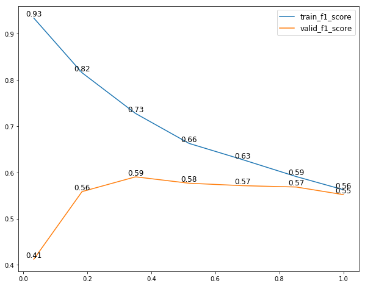

```python
plot_f1(f1_mult_lr_df, 'sample_frac')
```

Logistic regression is probably too simple a model for this problem. Let's look at another model.

## Model Selection - Random Forest

A more complex model which also allows a bit more customization is random forest. We will use these customizations to further improve the model performance

```python
def get_f1_by_sample_rf(mult, is_sample=True):
    if is_sample:
        X_train_sample, y_train_sample = select_sample(mult)
    else:
        X_train_sample, y_train_sample = X_train, y_train
    rfclassifier = RandomForestClassifier(n_estimators = 50, max_features = 10)
    rfclassifier.fit(X_train_sample, y_train_sample)
    train_f1_score, valid_f1_score = get_f1_score(rfclassifier, X_train_sample, X_valid, y_train_sample, y_valid)


    return {'sample_frac': X_train_sample.shape[0]/X_train.shape[0], 'train_f1_score': train_f1_score, 'valid_f1_score': valid_f1_score}
```

```python
f1_mult_rf = []
mult = 1
while mult < num_mults:
    f1_mult_rf.append(get_f1_by_sample_rf(mult))
    if mult==1:
        mult+=9
    else:
        mult+=10
f1_mult_rf.append(get_f1_by_sample_rf(_, is_sample=False))
```

```python
f1_mult_rf
```

```
[{'sample_frac': 0.033428571428571426,
  'train_f1_score': 0.9992872416250891,
  'valid_f1_score': 0.3571873055382701},
 {'sample_frac': 0.18385714285714286,
  'train_f1_score': 0.9992872416250891,
  'valid_f1_score': 0.6066897347174163},
 {'sample_frac': 0.351,
  'train_f1_score': 1.0,
  'valid_f1_score': 0.7300150829562595},
 {'sample_frac': 0.5181428571428571,
  'train_f1_score': 1.0,
  'valid_f1_score': 0.7582781456953641},
 {'sample_frac': 0.6852857142857143,
  'train_f1_score': 0.9992872416250891,
  'valid_f1_score': 0.7830687830687831},
 {'sample_frac': 0.8524285714285714,
  'train_f1_score': 0.9992872416250891,
  'valid_f1_score': 0.7876588021778584},
 {'sample_frac': 1.0,
  'train_f1_score': 0.9992872416250891,
  'valid_f1_score': 0.7480620155038761}]
```

```python
f1_mult_rf_df = pd.io.json.json_normalize(f1_mult_rf)
```

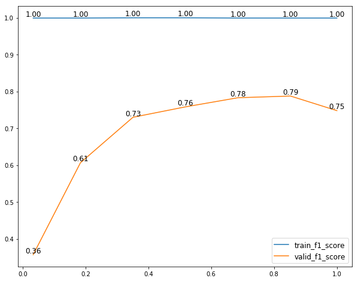

```python
plot_f1(f1_mult_rf_df, 'sample_frac')
```

Now we will try to change other parameters in random forest to see if that improves performance.

### Number of estimators

```python
X_train_sample, y_train_sample = select_sample(mult=50)
f1_est = []
num_estimators = 10
while num_estimators <= 100:
    rfclassifier = RandomForestClassifier(n_estimators = num_estimators, max_features = 10)
    rfclassifier.fit(X_train_sample, y_train_sample)
    train_f1_score, valid_f1_score = get_f1_score(rfclassifier, X_train_sample, X_valid, y_train_sample, y_valid)
    f1_est.append({'num_estimators': num_estimators, 'train_f1_score': train_f1_score, 'valid_f1_score': valid_f1_score})
    num_estimators+=10
```

```python
f1_est
```

```
[{'num_estimators': 10,
  'train_f1_score': 0.9848156182212581,
  'valid_f1_score': 0.725598526703499},
 {'num_estimators': 20,
  'train_f1_score': 0.9949892627057982,
  'valid_f1_score': 0.7568555758683729},
 {'num_estimators': 30,
  'train_f1_score': 0.9978586723768736,
  'valid_f1_score': 0.7719928186714541},
 {'num_estimators': 40,
  'train_f1_score': 1.0,
  'valid_f1_score': 0.7706093189964157},
 {'num_estimators': 50,
  'train_f1_score': 0.9992872416250891,
  'valid_f1_score': 0.7659574468085105},
 {'num_estimators': 60,
  'train_f1_score': 1.0,
  'valid_f1_score': 0.7843137254901962},
 {'num_estimators': 70,
  'train_f1_score': 0.9992872416250891,
  'valid_f1_score': 0.7785714285714287},
 {'num_estimators': 80,
  'train_f1_score': 0.9992872416250891,
  'valid_f1_score': 0.7885304659498207},
 {'num_estimators': 90,
  'train_f1_score': 1.0,
  'valid_f1_score': 0.793594306049822},
 {'num_estimators': 100,
  'train_f1_score': 1.0,
  'valid_f1_score': 0.773381294964029}]
```

```python
f1_est_df = pd.io.json.json_normalize(f1_est)
```

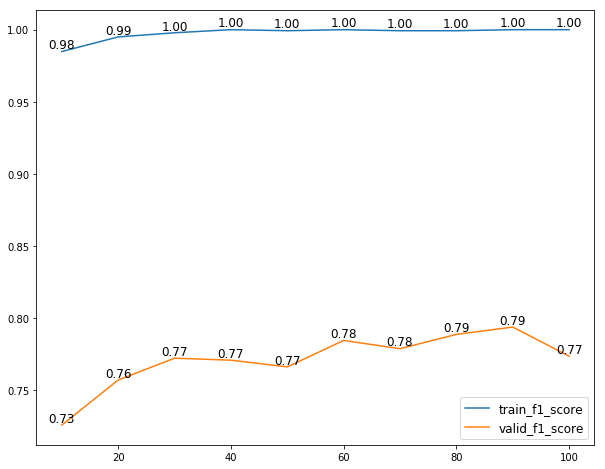

```python
plot_f1(f1_est_df, 'num_estimators')
```

```python
X_train_sample, y_train_sample = select_sample(mult=50)
f1_feat = []
max_features = 2
while max_features <= 20:
    rfclassifier = RandomForestClassifier(n_estimators = 60, max_features = max_features)
    rfclassifier.fit(X_train_sample, y_train_sample)
    train_f1_score, valid_f1_score = get_f1_score(rfclassifier, X_train_sample, X_valid, y_train_sample, y_valid)
    f1_feat.append({'max_features': max_features, 'train_f1_score': train_f1_score, 'valid_f1_score': valid_f1_score})
    max_features+=1
```

```python
f1_feat_df = pd.io.json.json_normalize(f1_feat)
```

```python
f1_feat_df
```

|  | max_features | train_f1_score | valid_f1_score |
| --- | --- | --- | --- |
| 0 | 2 | 1.000000 | 0.752727 |
| 1 | 3 | 1.000000 | 0.767273 |
| 2 | 4 | 0.998573 | 0.754513 |
| 3 | 5 | 0.999287 | 0.755396 |
| 4 | 6 | 0.999287 | 0.771429 |
| 5 | 7 | 0.999287 | 0.776770 |
| 6 | 8 | 1.000000 | 0.771171 |
| 7 | 9 | 1.000000 | 0.767568 |
| 8 | 10 | 1.000000 | 0.761566 |
| 9 | 11 | 1.000000 | 0.777778 |
| 10 | 12 | 1.000000 | 0.770053 |
| 11 | 13 | 1.000000 | 0.771681 |
| 12 | 14 | 0.999287 | 0.775439 |
| 13 | 15 | 0.999287 | 0.778761 |
| 14 | 16 | 0.999287 | 0.773050 |
| 15 | 17 | 0.999287 | 0.770318 |
| 16 | 18 | 1.000000 | 0.777385 |
| 17 | 19 | 0.999287 | 0.792254 |
| 18 | 20 | 0.998573 | 0.783217 |

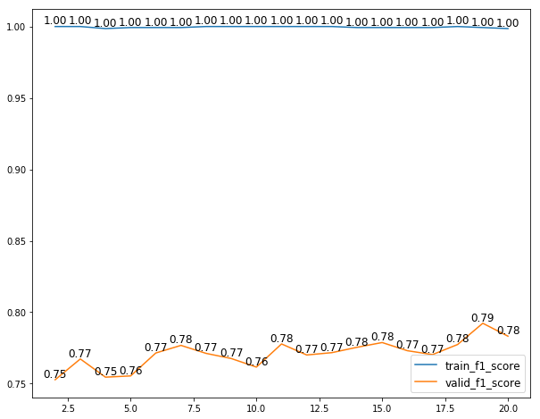

```python
plot_f1(f1_feat_df, 'max_features')
```

## Creating the submission

Now that we have selected the best model, we can use it on the test set.

```python
final_classifier = RandomForestClassifier(n_estimators = 60, max_features = 19)
final_classifier.fit(X_train_sample, y_train_sample)
```

```
RandomForestClassifier(bootstrap=True, class_weight=None, criterion='gini',
            max_depth=None, max_features=19, max_leaf_nodes=None,
            min_impurity_decrease=0.0, min_impurity_split=None,
            min_samples_leaf=1, min_samples_split=2,
            min_weight_fraction_leaf=0.0, n_estimators=60, n_jobs=1,
            oob_score=False, random_state=None, verbose=0,
            warm_start=False)
```

```python
get_f1_score(final_classifier, X_train_sample, X_valid, y_train_sample, y_valid)
```

```
(0.9985734664764622, 0.7740805604203153)
```

Since we already carried out all the necessary transformations on the test dataset, we can use it directly

```python
X_test = X[m:]
```

```python
y_test_preds = final_classifier.predict(X_test)
```

```python
submission = pd.DataFrame({'id': test_og.id, 'target': y_test_preds.astype(int)})
```

```python
submission.head()
```

|  | id | target |
| --- | --- | --- |
| 0 | 1 | 0 |
| 1 | 2 | 0 |
| 2 | 3 | 0 |
| 3 | 4 | 0 |
| 4 | 5 | 0 |

```python
submission.shape
```

```
(16001, 2)
```

```python
submission.to_csv('submission_dk_201910192153.csv',index=False)
```

## Reproducibility

Without knowing what the features actually mean, it is difficult to guess whether the model is reproducible

## Deployment

Since we performed a lot of transformations on the original data before creating the model, if new data is given to them model, it will also have to undergo the same transformations

### Remove NAs

```python
test_sample = test_og.sample(10).reset_index(drop=True)
```

```python
test_sample.replace('na', np.nan, inplace = True)
```

```python
test_sample_nonna = test_sample.fillna(data.mean())
```

### Scaling

```python
X_test_sample = scaler.transform(test_sample_nonna.iloc[:,1:])
```

```python
X_test_sample.shape
```

```
(10, 170)
```

```python
y_test_sample_preds = final_classifier.predict(X_test_sample)
```

### Saving model

As seen above, we need the model, scaler and mean to go from raw data to prediction. Thus we will save all of these for deployment.

Finally, we will wrap every step into its respective functions and call them at the appropriate time.

```python
data.mean().to_pickle('data_means.pkl')
```

```python
joblib.dump(scaler, 'scaler.pkl')
```

```
['scaler.pkl']
```

```python
joblib.dump(final_classifier, 'clf.pkl')
```

```
['clf.pkl']
```

Check out the [deployment app](https://equipfail.herokuapp.com/)